# Resampling Methods

## P1

Summary: Download the file 5.R.RData and load it into R using load(“5.R.RData”). Consider the linear regression model of y on X1 and X2. What is the standard error for beta1?

Task 1: Load data into R.

```r
load("5.R.RData")
summary(Xy)
```

```
##        X1                X2                y
##  Min.   :-0.8068   Min.   :-1.1753   Min.   :-0.75293
##  1st Qu.:-0.1674   1st Qu.:-0.2339   1st Qu.:-0.06136
##  Median : 0.2798   Median : 0.1824   Median : 0.30452
##  Mean   : 0.3337   Mean   : 0.1288   Mean   : 0.35471
##  3rd Qu.: 0.7017   3rd Qu.: 0.4646   3rd Qu.: 0.73283
##  Max.   : 1.8531   Max.   : 1.7658   Max.   : 2.03922
```

Task 2: Solve the linear regression model of y on x1 and x2.

```r
fit=lm(y~., data = Xy)
fit
```

```
##
## Call:
## lm(formula = y ~ ., data = Xy)
##
## Coefficients:
## (Intercept)           X1           X2
##      0.2658       0.1453       0.3134
```

```r
out <- summary(fit)
```

Task 3: Return the standard error for beta1.

```r
out$coefficients[2 ,2]
```

```
## [1] 0.02593295
```

Task 4: Next, plot the data using matplot(Xy,type=“l”).

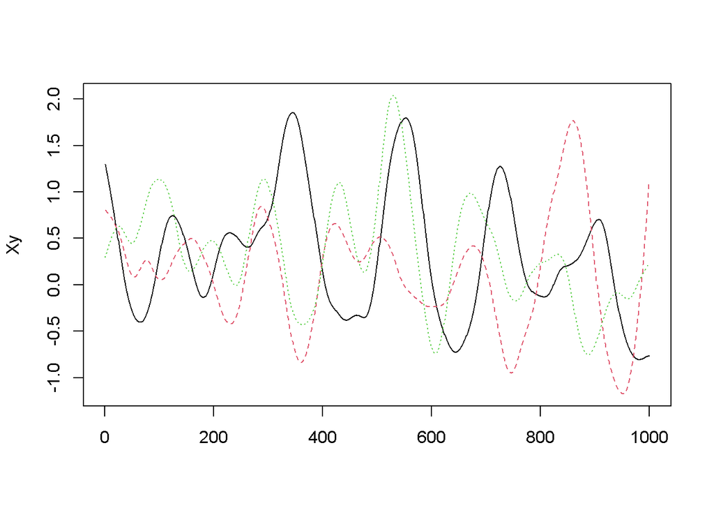

```r
matplot(Xy,type="l")
```

## P2

Summary: Now, use the (standard) bootstrap to estimate the standard error for beta1. To within 10%, what do you get?

Task 1: Load libraries.

```r
require(ISLR)
require(boot)
```

Task 2: Define bootstrap function.

```r
boot.fn=function(data, index) + return(coef(lm(y~., data=data, subset=index)))
```

Task 3: Perform bootstrap.

```r
set.seed(1)
boot.fn(Xy, sample(1:1000, 1000, replace = TRUE))
```

```
## (Intercept)          X1          X2
##   0.2714016   0.1668250   0.3821881
```

```r
out2 <- boot(Xy, boot.fn, 1000)
```

Task 4: Return the standard error for beta1.

```r
out2
```

```
##
## ORDINARY NONPARAMETRIC BOOTSTRAP
##
##
## Call:
## boot(data = Xy, statistic = boot.fn, R = 1000)
##
##
## Bootstrap Statistics :
##      original        bias    std. error
## t1* 0.2658349 -8.140169e-06  0.01441209
## t2* 0.1453263  1.181540e-03  0.02847033
## t3* 0.3133670  1.670687e-03  0.03526574
```

```r
sd(out2$t[ , 2])
```

```
## [1] 0.02847033
```

## P3

new.rows = c(101:200, 401:500, 101:200, 901:1000, 301:400, 1:100, 1:100, 801:900, 201:300, 701:800)

new.Xy = Xy[new.rows, ]

To within 10%, what do you get?

Task 1: Define time series bootstrap function.

```r
newboot.fn=function(data) + return(coef(lm(y~., data=data)))
```

Task 2: Perform bootstrap.

```r
set.seed(1)
out3 <- tsboot(Xy, statistic = newboot.fn, R = 1000, l = 100, sim = "fixed")
```

Task 3: Return the standard error for beta1.

```r
out3
```

```
##
## BLOCK BOOTSTRAP FOR TIME SERIES
##
## Fixed Block Length of 100
##
## Call:
## tsboot(tseries = Xy, statistic = newboot.fn, R = 1000, l = 100,
##     sim = "fixed")
##
##
## Bootstrap Statistics :
##      original        bias    std. error
## t1* 0.2658349 -0.0011871649  0.09355643
## t2* 0.1453263 -0.0008227603  0.19505853
## t3* 0.3133670  0.0617663497  0.30066695
```

```r
sd(out3$t[ , 2])
```

```
## [1] 0.1950585
```